# Cluster Analysis

```r
# features.clean
# features.outliers
# all.ex.pos.features.clean
# all.ex.pos.features
#
#
# dt.data.w.features_class = all.ex.pos.features
# dt.data.w.features_class[is.na(dt.data.w.features_class)] = 1000
# prediction = predict(classifier, dt.data.w.features_class)
# length(prediction[which(prediction == 1)])/length(prediction)

## check what stim_treatments get discarded!
outliers = which(prediction == 1)
a = table(dt.data.w.features_class[outliers,]$Stimulation_treatment)
b = table(dt.data.w.features_class[-outliers,]$Stimulation_treatment) # remove lots of plus control which is expected!


pos.ctrl.features_class = pos.ctrl.features
pos.ctrl.features_class[is.na(pos.ctrl.features_class)] = 1000
prediction = predict(classifier, pos.ctrl.features_class)
outliers_pos = which(prediction == 1)
c = table(pos.ctrl.features_class[outliers_pos,]$Stimulation_treatment)
d = table(pos.ctrl.features_class[-outliers_pos,]$Stimulation_treatment)
sum(table(pos.ctrl.features_class[outliers_pos,]$Stimulation_treatment))/length(pos.ctrl.features_class$Stimulation_treatment)
```

```
## [1] 0.6041009
```

```r
at = data.frame(a) %>% rename("Freq1" = Freq)
bt = data.frame(b) %>% rename("Freq2" = Freq)
outtable = dplyr::full_join(at, bt) %>% mutate(perc_outlier = Freq1/(Freq2+Freq1)) %>% mutate(perc_outlier = round(perc_outlier, digits = 3))
outtable = `colnames<-`(outtable, c("Treatment", "oultier", "not outlier", "precentage of outliers"))
knitr::kable(t(outtable))
```

| Treatment | -CTRL 0 | -CTRL 1 | -CTRL 10 | -CTRL 11 | -CTRL 12 | -CTRL 13 | -CTRL 14 | -CTRL 15 | -CTRL 16 | -CTRL 17 | -CTRL 2 | -CTRL 3 | -CTRL 4 | -CTRL 5 | -CTRL 6 | -CTRL 7 | -CTRL 8 | -CTRL 9 | A-Raf | B-Raf | C-Raf | CNKSR1 | CRKL | DIRAS1 | DIRAS2 | DUSP1 | DUSP10 | DUSP14 | DUSP16 | … |
| --- | --- | --- | --- | --- | --- | --- | --- | --- | --- | --- | --- | --- | --- | --- | --- | --- | --- | --- | --- | --- | --- | --- | --- | --- | --- | --- | --- | --- | --- | --- |
| oultier | 2 | 6 | 3 | 6 | 2 | 3 | 4 | 8 | 2 | 3 | 4 | 3 | 5 | 1 | 3 | 2 | 3 | 2 | 6 | 15 | 6 | 5 | 7 | 10 | 8 | 4 | 21 | 11 | 4 | … |
| not outlier | 34 | 43 | 38 | 61 | 37 | 52 | 79 | 57 | 36 | 48 | 22 | 37 | 27 | 39 | 47 | 34 | 62 | 24 | 57 | 92 | 54 | 87 | 97 | 91 | 57 | 81 | 48 | 91 | 70 | … |
| precentage of outliers | 0.056 | 0.122 | 0.073 | 0.090 | 0.051 | 0.055 | 0.048 | 0.123 | 0.053 | 0.059 | 0.154 | 0.075 | 0.156 | 0.025 | 0.060 | 0.056 | 0.046 | 0.077 | 0.095 | 0.140 | 0.100 | 0.054 | 0.067 | 0.099 | 0.123 | 0.047 | 0.304 | 0.108 | 0.054 | … |

## features_20190311_systIII_siPOOLs_plate1and2_singlePulses_rec_filtered.csv

Loading of the necessary Data and transfering

```r
data.clean = data.table::fread(filename.features)
dt.data = fread(filename.tdata)
```

Pool all the WT and negative as well as posive CTRL together

```r
features.clean.pooled = data.clean %>% mutate(Stimulation_treatment = case_when(
  Stimulation_treatment %like% "\\+CTRL" ~ "+CTRL",
  Stimulation_treatment %like% "\\-CTRL" ~ "-CTRL",
  Stimulation_treatment %like% "WT" ~ "WT",
  TRUE ~ as.character(Stimulation_treatment)
) )
```

Normalisation of the data

```r
source("normalize_data_frame.R")
data.pooled.n = normalize_frame(features.clean.pooled, -site.var, -track.var)
```

Create named matrix of the normalized features

```r
names = data.pooled.n %>% pull(var = stim.var)
cluster.data.n = data.pooled.n %>% ungroup()  %>%
  select(-site.var, -track.var) %>% #, -dip.time.min, -mean, -sd, -FMWH.left, -FMWH.right, -noise) %>%
  select_if(is.numeric)
m = as.matrix(cluster.data.n)
rownames(m) = names
```

Create distance matrx and cluster with hc clust

```r
distance_m = dist(m, method = "euclidean")
hr <- hclust(distance_m, method = "ward.D2")
```

Clustered Heatmap of features with 5 Clusters

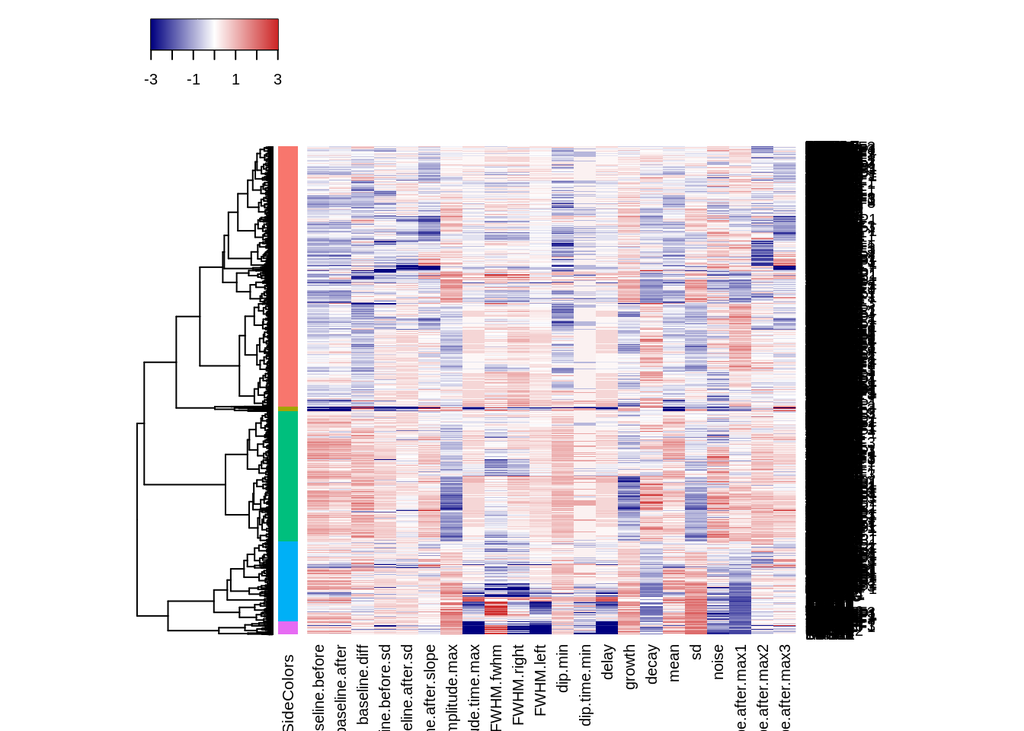

```r
mycl <- cutree(hr, k = k)
cl = as.factor(mycl)
gg_color_hue <- function(n) {
  hues = seq(15, 375, length = n + 1)
  hcl(h = hues, l = 65, c = 100)[1:n]
}
mycolhc <- gg_color_hue(k)
mycolhc_c <- mycolhc[as.integer(as.vector(cl))]
m_clipped = m # hard clipping, ouliers disturbe colors
m_clipped[m_clipped > 3 ] = 3
m_clipped[m_clipped < -3] = -3
heatmap3(m_clipped, Rowv =as.dendrogram(hr), Colv = NA, scale = "none", RowSideColors = mycolhc_c)
```

Heat map but with Columns clustered aswell

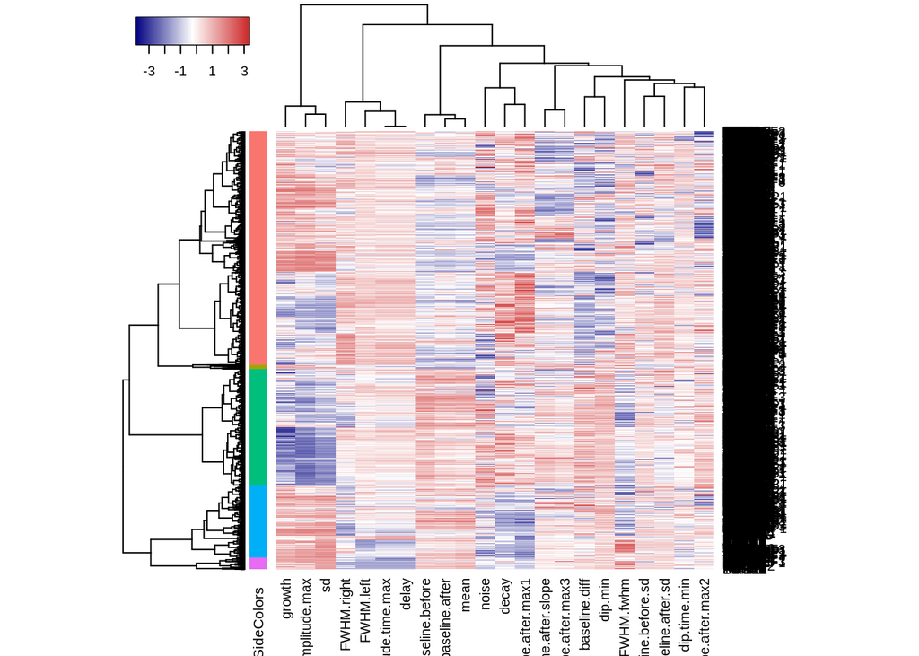

```r
distance_m_c = dist(t(m), method = "euclidean")
hc <- hclust(distance_m_c, method = "ward.D")
heatmap3(m_clipped, Rowv =as.dendrogram(hr), Colv = as.dendrogram(hc), RowSideColors = mycolhc_c)
```

From dendrogram, get cluster information and create cluster distance plot.

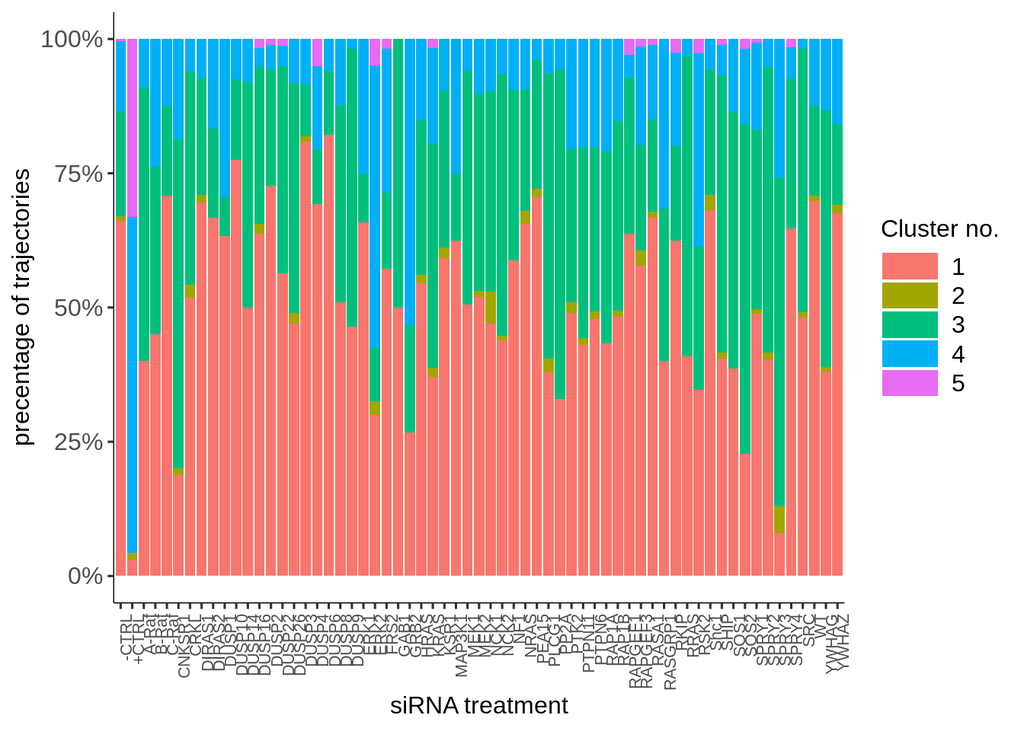

```r
cluster.freq = data.frame(cl = as.vector(mycl), type = names(mycl))
summ = cluster.freq %>% group_by(cl, type) %>% summarise(count = n())  %>% ungroup() %>% mutate(cl = as.factor(cl))

ggplot(summ,aes(x = type, y = count, fill = cl)) +
    geom_bar(position = position_fill(reverse = TRUE),stat = "identity") +
    scale_y_continuous(labels = scales::percent_format()) +
    ggplotTheme() + theme(axis.text.x = element_text(angle = 90, hjust = 1, size = 8)) +
    labs(y = "precentage of trajectories", fill = "Cluster no.", x = "siRNA treatment")
```

File containing for the Features and therefore for the unique label in which clusters it belongs. Merge with time series data to plot cluster averages

Analyse clusters averages

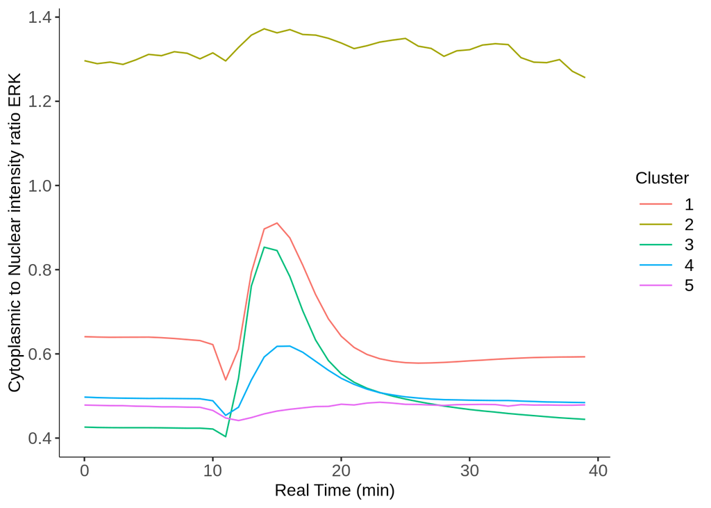

```r
# should still have same ordering as features table
cluster.freq = mutate(cluster.freq,Image_Metadata_Site = data.clean %>% pull(site.var))
cluster.freq = mutate(cluster.freq,track_id = data.clean %>% pull(track.var))
# cluster.freq$Image_Metadata_Site = data.clean$Image_Metadata_Site
# cluster.freq$objNuc_TrackObjects_Label = data.clean$objNuc_TrackObjects_Label

timeseries.clustered = left_join(cluster.freq, dt.data)

summarised_clusters = timeseries.clustered %>%
  mutate(cl = as.factor(cl)) %>%
  group_by_("cl", time.var) %>% summarise(mean_cl_at_t = mean(erk.ratio))
ggplot(summarised_clusters, aes(y = mean_cl_at_t, x = get(time.var), color =  cl, group = cl)) +
  geom_line() +
  labs(x = "Real Time (min)" , y = "Cytoplasmic to Nuclear intensity ratio ERK", color = "Cluster") +
  ggplotTheme()
```

## train a randomForest classifier on the features. Create a model that predicts Stimulation_Treatment and look at feature importance.

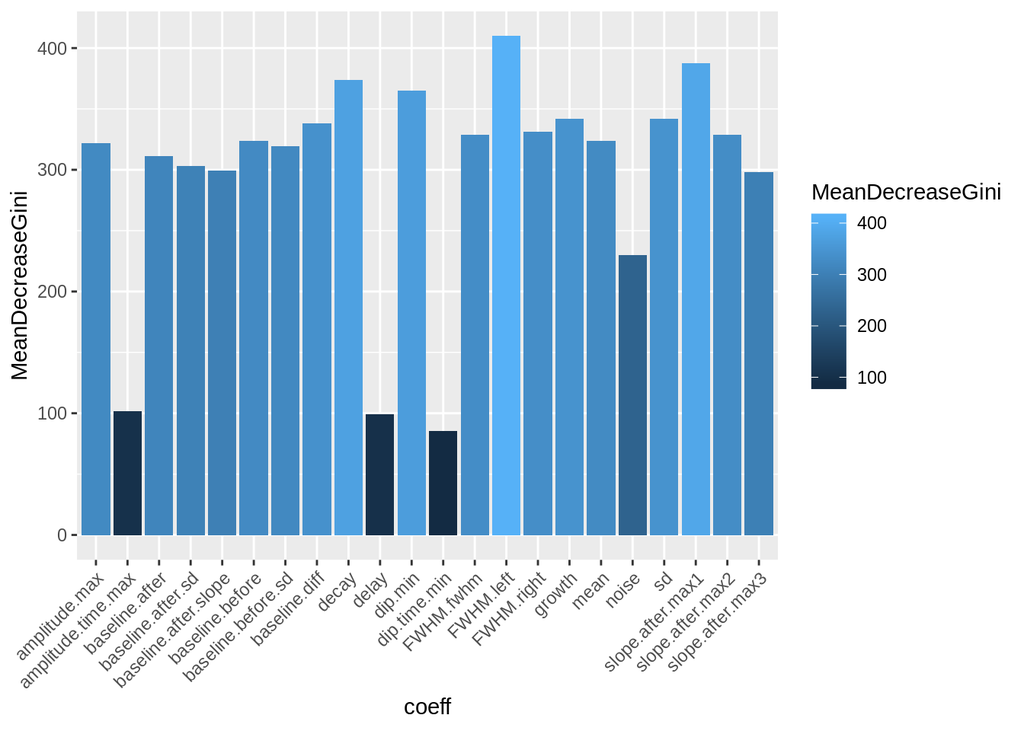

```r
#rnd.features = data.clean
rnd.features = features.clean.pooled
rnd.features[is.na(rnd.features)] = 1000
rnd.features = select(rnd.features, -site.var)
rnd.features = select(rnd.features, -track.var)
rnd.features = mutate(rnd.features,Stimulation_treatment = as.factor(get(stim.var)))
forest_class = randomForest(Stimulation_treatment~.,rnd.features)
coeff = as.data.table(importance(forest_class))
coeff$coeff = rownames(importance(forest_class))


ggplot(coeff, aes(y = MeanDecreaseGini, x = coeff, fill = MeanDecreaseGini)) +
  geom_bar(stat = "identity")+
  theme(axis.text.x = element_text(angle = 45, hjust = 1))
```

## Repetition of clustering Analysis with only important features according to random Forest

```r
arrange(coeff, MeanDecreaseGini)[-(1:5),]$coeff
```

```
##  [1] "baseline.after.slope" "baseline.after.sd"    "baseline.after"
##  [4] "baseline.before.sd"   "amplitude.max"        "baseline.before"
##  [7] "mean"                 "slope.after.max2"     "FWHM.fwhm"
## [10] "FWHM.right"           "baseline.diff"        "sd"
## [13] "growth"               "dip.min"              "decay"
## [16] "slope.after.max1"     "FWHM.left"
```

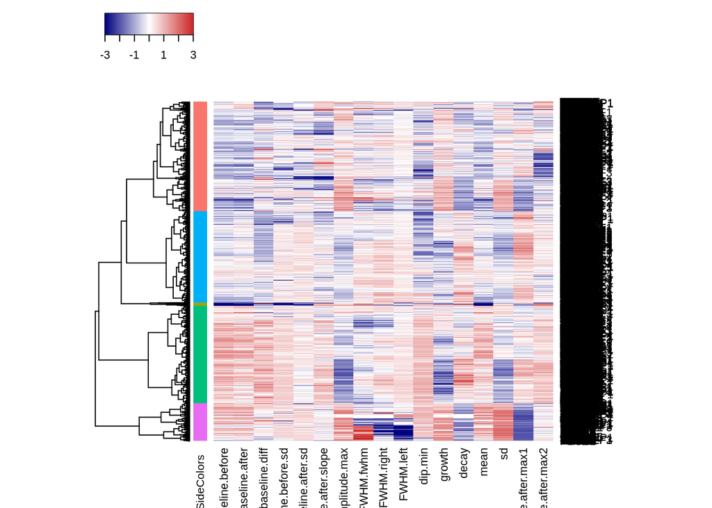

```r
names = data.pooled.n %>% pull(stim.var)
cluster.data.n = data.pooled.n %>% ungroup()  %>%
  select(-site.var, -track.var) %>% select(-c(arrange(coeff, MeanDecreaseGini)[1:5,]$coeff)) %>%#, -dip.time.min, -mean, -sd, -FMWH.left, -FMWH.right, -noise) %>%
  select_if(is.numeric)
m = as.matrix(cluster.data.n)
rownames(m) = names
distance_m = dist(m, method = "euclidean")
hr <- hclust(distance_m, method = "ward.D2")
mycl <- cutree(hr, k = k)
cl = as.factor(mycl)
gg_color_hue <- function(n) {
  hues = seq(15, 375, length = n + 1)
  hcl(h = hues, l = 65, c = 100)[1:n]
}
mycolhc <- gg_color_hue(k)
mycolhc_c <- mycolhc[as.integer(as.vector(cl))]
m_clipped = m # hard clipping, ouliers disturbe colors
m_clipped[m_clipped > 3 ] = 3
m_clipped[m_clipped < -3] = -3
heatmap3(m_clipped, Rowv =as.dendrogram(hr), Colv = NA, scale = "none", RowSideColors = mycolhc_c)
```

Heat map but with Columns clustered aswell

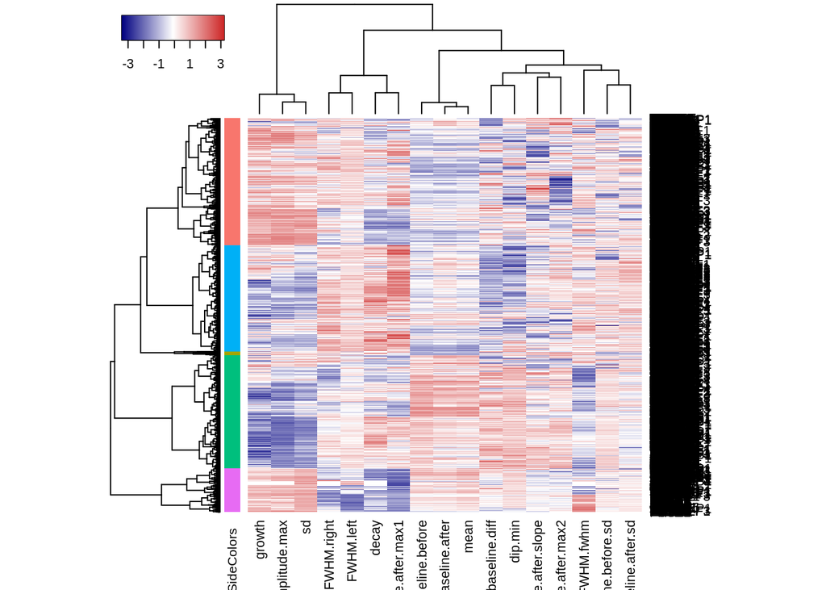

```r
distance_m_c = dist(t(m), method = "euclidean")
hc <- hclust(distance_m_c, method = "ward.D")
#pdf("heatmap")
heatmap3(m_clipped, Rowv =as.dendrogram(hr), Colv = as.dendrogram(hc), RowSideColors = mycolhc_c)
```

```r
#dev.off()
```

From dendrogram, get cluster information and create cluster distance plot.

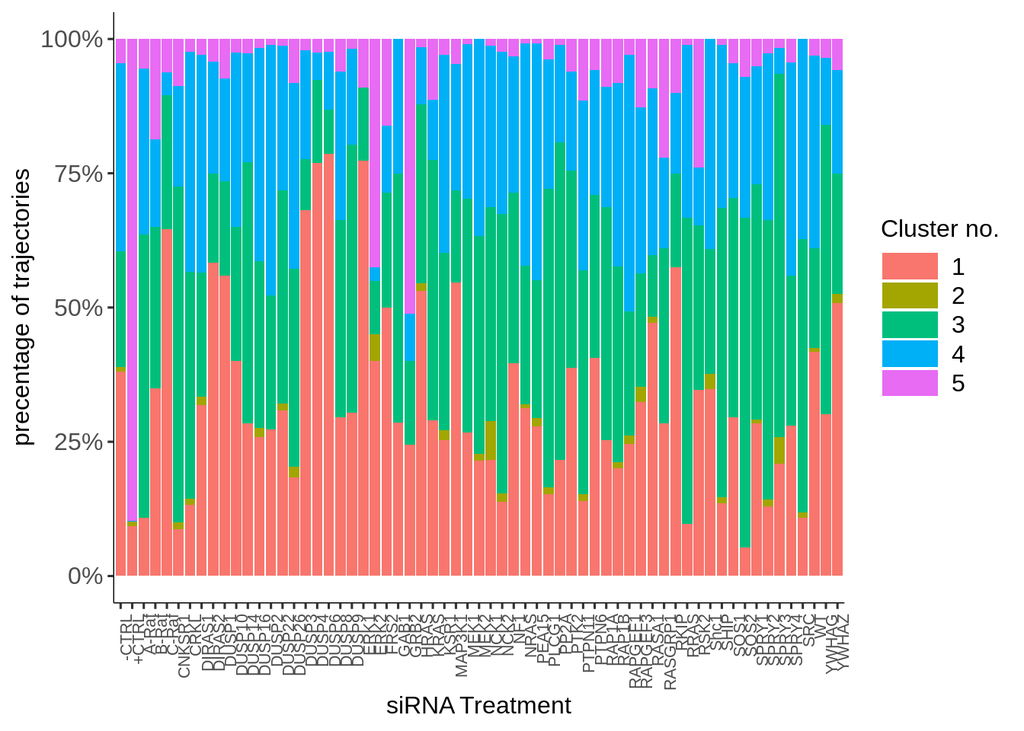

```r
cluster.freq = data.frame(cl = as.vector(mycl), type = names(mycl))
summ = cluster.freq %>% group_by(cl, type) %>% summarise(count = n())  %>% ungroup() %>% mutate(cl = as.factor(cl))

gga = ggplot(summ,aes(x = type, y = count, fill = cl)) +
    geom_bar(position = position_fill(reverse = TRUE),stat = "identity") +
    scale_y_continuous(labels = scales::percent_format()) +
    ggplotTheme() + theme(axis.text.x = element_text(angle = 90, hjust = 1, size = 8)) +
    labs(y = "precentage of trajectories", fill = "Cluster no.", x = "siRNA Treatment")
plot(gga)
```

```r
ggsave(filename = "clusterdist_ggplot", plot = gga, device = "svg")
```

File containing for the Features and therefore for the unique label in which clusters it belongs. Merge with time series data to plot cluster averages

Analyse clusters averages

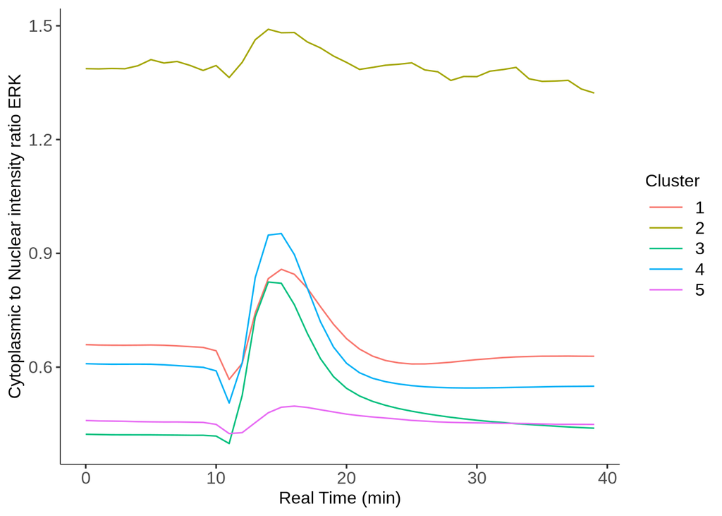

```r
# should still have same ordering as features table
cluster.freq = mutate(cluster.freq,Image_Metadata_Site = data.clean %>% pull(site.var))
cluster.freq = mutate(cluster.freq,track_id = data.clean %>% pull(track.var))
# cluster.freq$Image_Metadata_Site = data.clean$Image_Metadata_Site
# cluster.freq$objNuc_TrackObjects_Label = data.clean$objNuc_TrackObjects_Label

timeseries.clustered = left_join(cluster.freq, dt.data)

summarised_clusters = timeseries.clustered %>%
  mutate(cl = as.factor(cl)) %>%
  group_by_("cl", time.var) %>% summarise(mean_cl_at_t = mean(erk.ratio))

gg = ggplot(summarised_clusters, aes(y = mean_cl_at_t, x = get(time.var), color =  cl, group = cl)) +
  geom_line() +
  labs(x = "Real Time (min)" , y = "Cytoplasmic to Nuclear intensity ratio ERK", color = "Cluster") +
  ggplotTheme()
plot(gg)
```

```r
ggsave(filename = "clusteraverages_ggplot", plot = gg, device = "svg")
```

## Remove positive CTRL from clustering

```r
k = 8 # without +CTRL is ok
arrange(coeff, MeanDecreaseGini)[-(1:5),]$coeff
```

```
##  [1] "baseline.after.slope" "baseline.after.sd"    "baseline.after"
##  [4] "baseline.before.sd"   "amplitude.max"        "baseline.before"
##  [7] "mean"                 "slope.after.max2"     "FWHM.fwhm"
## [10] "FWHM.right"           "baseline.diff"        "sd"
## [13] "growth"               "dip.min"              "decay"
## [16] "slope.after.max1"     "FWHM.left"
```

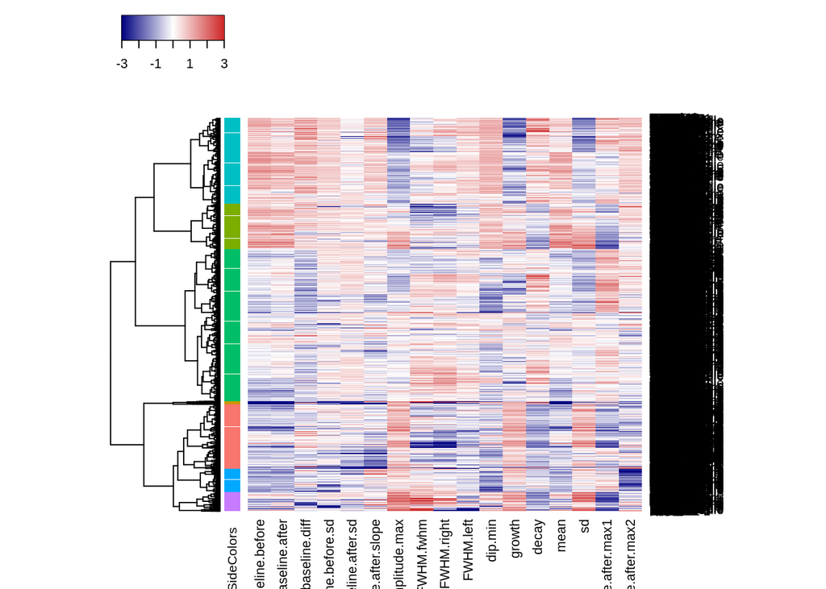

```r
data.pooled = data.clean %>%
  filter(!get(stim.var) %like% "\\+CTRL") %>%
  mutate(Stimulation_treatment = case_when(stim.var %like% "WT" ~ "WT",
                                           stim.var %like% "CTRL" ~ "-CTRL",
                                           TRUE ~ as.character(get(stim.var))))
data.pooled.n = normalize_frame(data.pooled, -site.var, -track.var)


names = data.pooled.n %>% pull(stim.var)
cluster.data.n = data.pooled.n %>% ungroup()  %>%
  select(-site.var, -track.var) %>% select(-c(arrange(coeff, MeanDecreaseGini)[1:5,]$coeff)) %>%#, -dip.time.min, -mean, -sd, -FMWH.left, -FMWH.right, -noise) %>%
  select_if(is.numeric)
m = as.matrix(cluster.data.n)
rownames(m) = names
distance_m = dist(m, method = "euclidean")
hr <- hclust(distance_m, method = "ward.D2")
mycl <- cutree(hr, k = k)
cl = as.factor(mycl)
gg_color_hue <- function(n) {
  hues = seq(15, 375, length = n + 1)
  hcl(h = hues, l = 65, c = 100)[1:n]
}
mycolhc <- gg_color_hue(k)
mycolhc_c <- mycolhc[as.integer(as.vector(cl))]
m_clipped = m # hard clipping, ouliers disturbe colors
m_clipped[m_clipped > 3 ] = 3
m_clipped[m_clipped < -3] = -3
heatmap3(m_clipped, Rowv =as.dendrogram(hr), Colv = NA, scale = "none", RowSideColors = mycolhc_c)
```

Heat map but with Columns clustered aswell

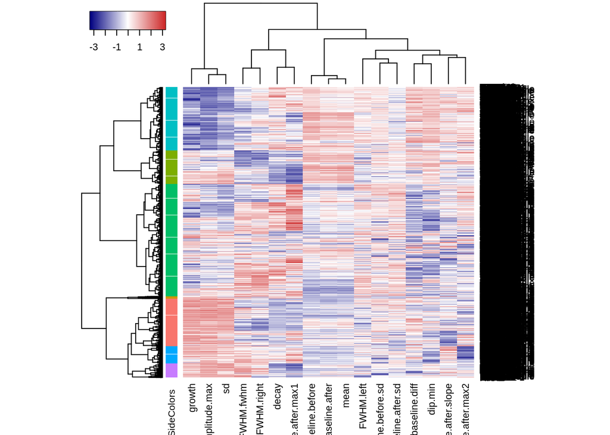

```r
distance_m_c = dist(t(m), method = "euclidean")
hc <- hclust(distance_m_c, method = "ward.D")
heatmap3(m_clipped, Rowv =as.dendrogram(hr), Colv = as.dendrogram(hc), RowSideColors = mycolhc_c)
```

From dendrogram, get cluster information and create cluster distance plot.

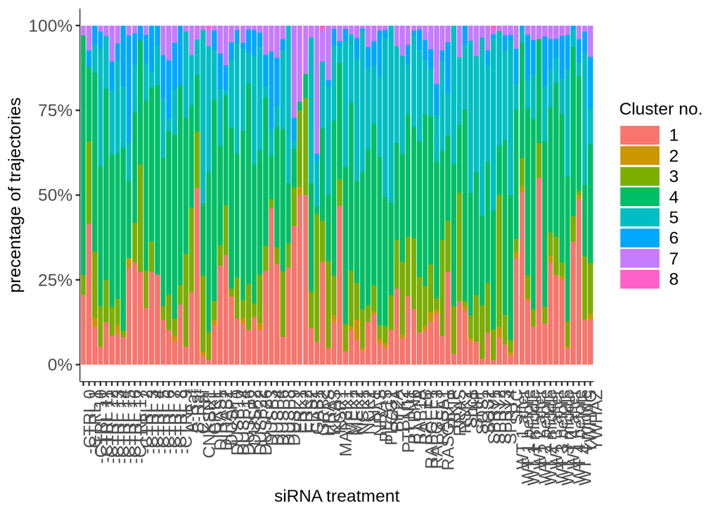

```r
cluster.freq = data.frame(cl = as.vector(mycl), type = names(mycl))
summ = cluster.freq %>% group_by(cl, type) %>% summarise(count = n())  %>% ungroup() %>% mutate(cl = as.factor(cl))

ggplot(summ,aes(x = type, y = count, fill = cl)) +
    geom_bar(position = position_fill(reverse = TRUE),stat = "identity") +
    scale_y_continuous(labels = scales::percent_format()) +
    ggplotTheme() + theme(axis.text.x = element_text(angle = 90, hjust = 1)) +
    labs(y = "precentage of trajectories", fill = "Cluster no.", x = "siRNA treatment")
```

File containing for the Features and therefore for the unique label in which clusters it belongs. Merge with time series data to plot cluster averages

Analyse clusters averages

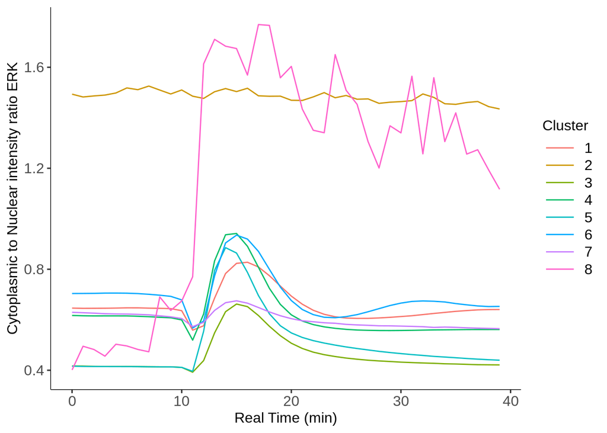

```r
# should still have same ordering as features table
cluster.freq = mutate(cluster.freq,Image_Metadata_Site = data.pooled.n %>% pull(site.var))
cluster.freq = mutate(cluster.freq,track_id = data.pooled.n %>% pull(track.var))
# cluster.freq$Image_Metadata_Site = data.pooled.n$Image_Metadata_Site
# cluster.freq$objNuc_TrackObjects_Label = data.pooled.n$objNuc_TrackObjects_Label

timeseries.clustered = left_join(cluster.freq, dt.data)

summarised_clusters = timeseries.clustered %>%
  mutate(cl = as.factor(cl)) %>%
  group_by_("cl", time.var) %>% summarise(mean_cl_at_t = mean(erk.ratio))

ggplot(summarised_clusters, aes(y = mean_cl_at_t, x = get(time.var), color =  cl, group = cl)) +
  geom_line() +
  labs(x = "Real Time (min)" , y = "Cytoplasmic to Nuclear intensity ratio ERK", color = "Cluster") +
  ggplotTheme()
```

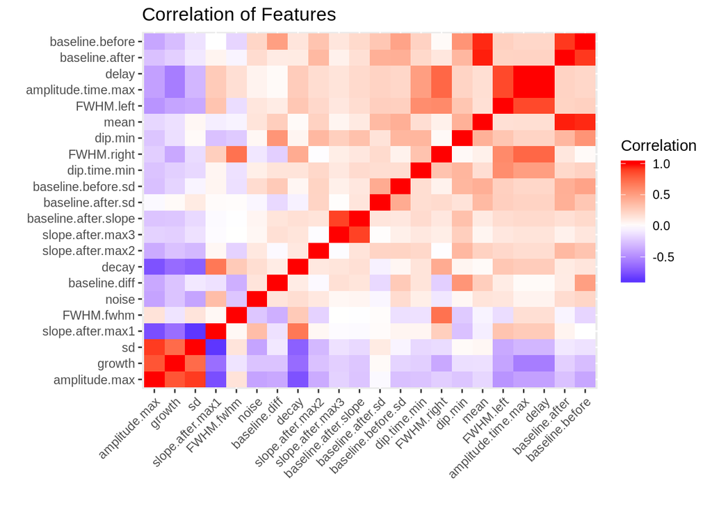

```r
names = data.pooled.n$Stimulation_treatment
cluster.data.n = data.pooled.n %>% ungroup()  %>%
  select(-site.var, -track.var) %>% #, -dip.time.min, -mean, -sd, -FMWH.left, -FMWH.right, -noise) %>%
  select_if(is.numeric)
m = as.matrix(cluster.data.n)
fcorr = cor(na.omit(m))
fcorr.df = data.frame(fcorr)
fcorr.df$type = rownames(fcorr.df)
cor.long = gather(fcorr.df, "type1","Correlation",-type)
ggplot(cor.long, aes(y = reorder(type, Correlation), x = reorder(type1, Correlation), fill = Correlation)) +
  geom_tile() + scale_fill_gradient2(low = "blue", high= "red", mid = "white") +
  theme(axis.text.x = element_text(angle = 45, hjust = 1)) + labs(title = "Correlation of Features" , x = "" , y = "")
```

Correlation after removing Features accoring to importance created by random Forest.

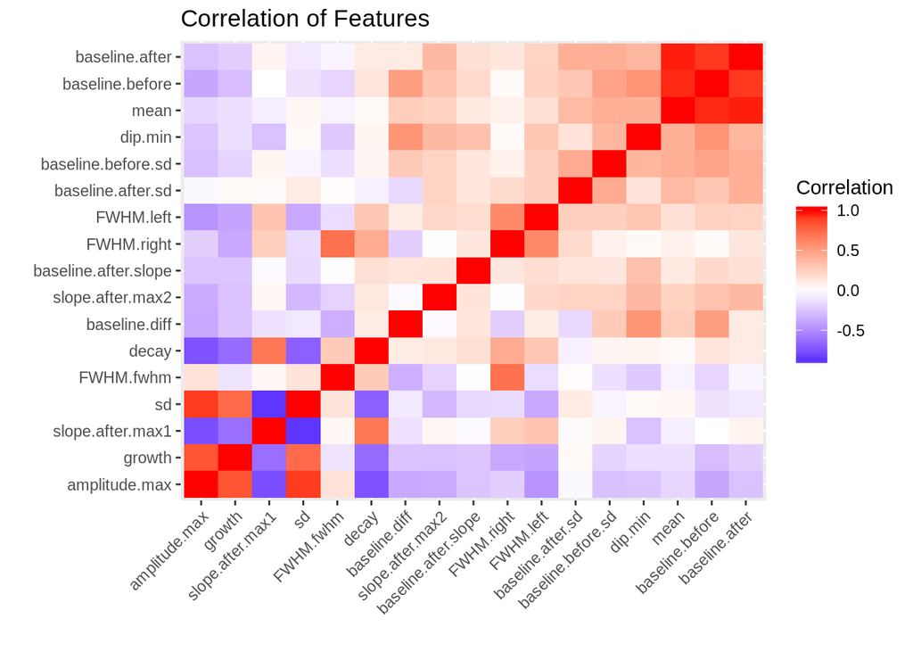

```r
names = data.pooled.n %>% pull(site.var)
cluster.data.n = data.pooled.n %>% ungroup()  %>%
  select(-site.var, -track.var) %>%
  select(-c(arrange(coeff, MeanDecreaseGini)[1:5,]$coeff)) %>% #, -dip.time.min, -mean, -sd, -FMWH.left, -FMWH.right, -noise) %>%
  select_if(is.numeric)
m = as.matrix(cluster.data.n)
fcorr = cor(na.omit(m))
fcorr.df = data.frame(fcorr)
fcorr.df$type = rownames(fcorr.df)
cor.long = gather(fcorr.df, "type1","Correlation",-type)
ggplot(cor.long, aes(y = reorder(type, Correlation), x = reorder(type1, Correlation), fill = Correlation)) +
  geom_tile() + scale_fill_gradient2(low = "blue", high= "red", mid = "white") +
  theme(axis.text.x = element_text(angle = 45, hjust = 1)) + labs(title = "Correlation of Features" , x = "" , y = "")
```

```r
require(Rtsne)

# # try tsne stuff
# labels = na.omit(data.pooled.n) %>% pull(stim.var)
# train<- data.pooled.n %>% select(-site.var, -track.var, -stim.var)## Choose the train.csv file downloaded from the link above
# ## Curating the database for analysis with both t-SNE and PCA
#
# labels<-as.factor(labels)
# ## for plotting
# colors = rainbow(length(unique(labels)))
# names(colors) = unique(labels)
#
# ## Executing the algorithm on curated data
# tsne <- Rtsne(na.omit(train), dims = 2, perplexity=50, verbose=TRUE, max_iter = 1800, eta = 300)
#
# ## Plotting
# x = data.frame(tsne$Y)
# x$type = labels
# ggplot(x, aes(x = X1, y = X2, color = type)) +
#   geom_point() + theme_classic()
```